# Group6_CSCN8010_Final_Project

the unit_of_wage has 4 distinct values hour, week, month and year. About 90% of the wages are yearly.

Among the applicants with Hourly wage, visa approval percentage is about 37%. The visa certified percentage for Weekly, monthly and yearly are around 60%, 60% and 65% respectively.

Full time position

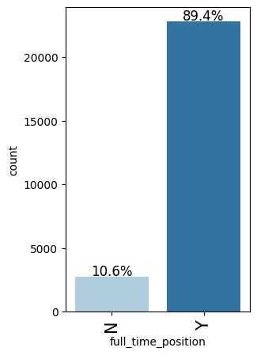

```
case_status             0     1    All
full_time_position
All                 17018  8462  25480
Y                   15163  7610  22773
N                    1855   852   2707
------------------------------------------------------------------------------------------------------------------------
```

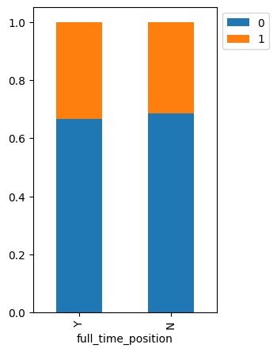

```python
labeled_barplot(data,'full_time_position',perc=True)
stacked_barplot(data,'full_time_position','case_status')
```

**Let's see the attributes that have a strong correlation with each other**

**Correlation Check**

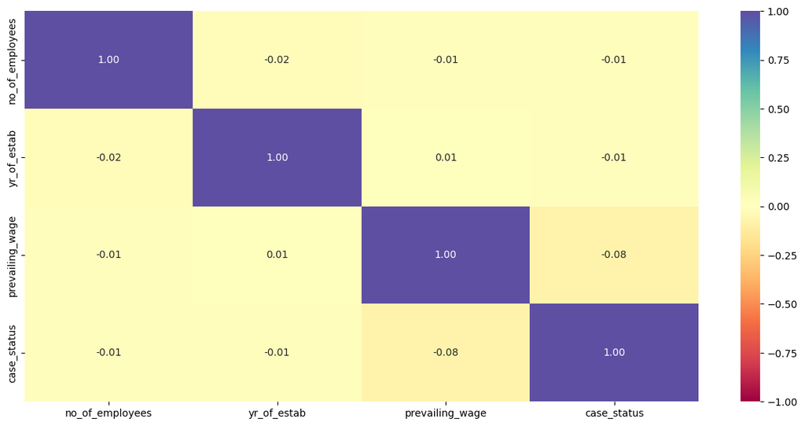

```python
plt.figure(figsize=(15, 7))
sns.heatmap(data.corr(numeric_only=True), annot=True, vmin=-1, vmax=1, fmt=".2f", cmap="Spectral")
plt.show()
```

Lets check pair plot

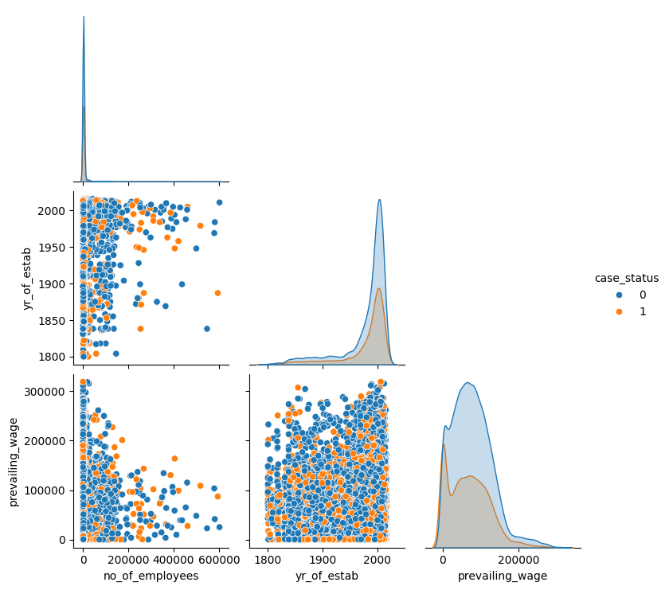

```python
sns.pairplot(data,hue='case_status',corner=True)
```

There is no strong correlation between any of the numeric fields as seen above.

## Data Preprocessing

### Outlier Detection

```python
# Convert relevant columns to numeric type before calculating quantiles.
# This assumes 'no_of_employees', 'yr_of_estab', and 'prevailing_wage' are the relevant numeric columns.
for col in ['no_of_employees', 'yr_of_estab', 'prevailing_wage']:
    data[col] = pd.to_numeric(data[col], errors='coerce')

Q1 = data.quantile(0.25, numeric_only=True)  # To find the 25th percentile
Q3 = data.quantile(0.75, numeric_only=True)  # To find the 75th percentile

IQR = Q3 - Q1  # Inter Quantile Range (75th perentile - 25th percentile)

# Finding lower and upper bounds for all values. All values outside these bounds are outliers
lower = (Q1 - 1.5 * IQR)
upper = (Q3 + 1.5 * IQR)
```

```python
# checking the % outliers
((data.select_dtypes(include=["float64", "int64"]) < lower) | (data.select_dtypes(include=["float64", "int64"]) > upper)).sum() / len(data) * 100
```

|  | 0 |
| --- | --- |
| no_of_employees | 6.107 |
| yr_of_estab | 12.794 |
| prevailing_wage | 1.676 |
| case_status | 0.000 |

**dtype:** float64

### Train-Test Split

```python
# creating the copy of the dataframe
df = data.copy()
```

```python
df.isna().sum()
```

|  | 0 |
| --- | --- |
| continent | 0 |
| education_of_employee | 0 |
| has_job_experience | 0 |
| requires_job_training | 0 |
| no_of_employees | 0 |
| yr_of_estab | 0 |
| region_of_employment | 0 |
| prevailing_wage | 0 |
| unit_of_wage | 0 |
| full_time_position | 0 |
| case_status | 0 |

**dtype:** int64

```python
df.duplicated().sum()
```

```
np.int64(0)
```

As seen from the above, we can deduce that there are no duplicated records or missing values.

Let's split the data for modeling

```python
# Dividing train data into X and y
X = df.drop(["case_status"], axis=1)
y = df["case_status"]
```

```python
# Splitting data into training, validation and test sets:
# first we split data into 2 parts, say temporary and test

X_temp, X_test, y_temp, y_test = train_test_split(
    X, y, test_size=0.2, random_state=1, stratify=y
)

# then we split the temporary set into train and validation

X_train, X_val, y_train, y_val = train_test_split(
    X_temp, y_temp, test_size=0.25, random_state=1, stratify=y_temp
)
print(X_train.shape, X_val.shape, X_test.shape)
```

```
(15288, 10) (5096, 10) (5096, 10)
```

Data cleaning and preprocessing

```python
df[df['no_of_employees']<0].value_counts()
```

| continent | education_of_employee | has_job_experience | requires_job_training | no_of_employees | yr_of_estab | region_of_employment | prevailing_wage | unit_of_wage | full_time_position | case_status | count |
| --- | --- | --- | --- | --- | --- | --- | --- | --- | --- | --- | --- |
| Africa | Master's | Y | N | -25 | 1977 | Midwest | 79150.510 | Year | Y | 0 | 1 |
| Asia | Bachelor's | N | N | -26 | 2004 | South | 84359.980 | Year | Y | 1 | 1 |
|  |  |  |  | -14 | 2012 | West | 29325.850 | Year | Y | 1 | 1 |
|  |  |  |  |  | 2013 | South | 103.970 | Hour | Y | 1 | 1 |
|  |  |  |  |  | 2014 | South | 24641.610 | Year | Y | 1 | 1 |
|  |  |  | Y | -26 | 1954 | West | 81982.270 | Year | Y | 0 | 1 |
|  |  |  |  | -17 | 1990 | West | 91897.570 | Year | Y | 0 | 1 |
|  |  |  |  | -11 | 1946 | Northeast | 108403.560 | Year | Y | 0 | 1 |
|  |  |  |  |  | 2011 | Northeast | 32506.140 | Year | Y | 1 | 1 |
|  |  | Y | N | -26 | 1923 | West | 5247.320 | Year | Y | 1 | 1 |
|  |  |  |  | -25 | 2000 | West | 100463.580 | Year | Y | 0 | 1 |
|  |  |  | Y | -26 | 2006 | South | 115005.610 | Year | Y | 0 | 1 |
|  | Doctorate | Y | N | -11 | 1984 | West | 25753.510 | Year | Y | 1 | 1 |
|  | High School | N | N | -14 | 2000 | Midwest | 58488.500 | Year | Y | 1 | 1 |
|  |  |  |  | -11 | 1969 | South | 44640.600 | Year | Y | 1 | 1 |
|  |  | Y | N | -14 | 1999 | South | 27599.350 | Year | Y | 1 | 1 |
|  | Master's | N | N | -11 | 2000 | Midwest | 167851.800 | Year | Y | 0 | 1 |
|  |  |  |  |  | 2009 | Midwest | 38457.510 | Year | Y | 0 | 1 |
|  |  |  | Y | -11 | 2007 | Midwest | 120195.350 | Year | Y | 0 | 1 |
|  |  | Y | N | -26 | 2005 | Midwest | 112799.460 | Year | Y | 0 | 1 |
|  |  |  |  | -14 | 1986 | South | 17893.110 | Year | Y | 0 | 1 |
|  |  |  |  | -11 | 1994 | South | 62681.250 | Year | Y | 0 | 1 |
| Europe | Doctorate | N | N | -25 | 1998 | Midwest | 141435.950 | Year | Y | 0 | 1 |
|  |  | Y | N | -14 | 1989 | Midwest | 37012.800 | Year | Y | 0 | 1 |
|  | Master's | N | N | -25 | 1980 | Northeast | 39452.990 | Year | Y | 0 | 1 |
|  |  | Y | N | -26 | 1996 | South | 37397.050 | Year | Y | 0 | 1 |
|  |  |  |  | -11 | 2000 | West | 95072.750 | Year | Y | 1 | 1 |
| North America | Bachelor's | Y | N | -26 | 1968 | Northeast | 168.156 | Hour | Y | 1 | 1 |
|  |  |  |  | -17 | 2007 | Northeast | 129753.180 | Year | Y | 1 | 1 |
|  |  |  |  | -14 | 1980 | West | 691.061 | Hour | Y | 1 | 1 |
|  | High School | N | N | -25 | 1987 | South | 99405.470 | Year | N | 1 | 1 |
|  | Master's | N | N | -17 | 2003 | Northeast | 257.241 | Hour | Y | 1 | 1 |
| South America | Master's | Y | N | -17 | 2002 | South | 129701.940 | Year | Y | 0 | 1 |

**dtype:** int64

As observed from the above data, we can find that there are about 33 records with negatives in no_of_employees field.

We will now replace -ves with positive values by taking median of the positive data.

we will repeat this step separately for train, test and validation data sets to prevent data leakage

Data cleaning, negative number of employees

```python
#X_train

posEmpTrain = X_train[X_train['no_of_employees'] > 0]['no_of_employees']
medianPosEmpTrain = posEmpTrain.median()
X_train['no_of_employees'] = np.where(X_train['no_of_employees'] < 0, medianPosEmpTrain, X_train['no_of_employees'])

#X_val

posEmpVal = X_val[X_val['no_of_employees'] > 0]['no_of_employees']
medianPosEmpVal = posEmpVal.median()
X_val['no_of_employees'] = np.where(X_val['no_of_employees'] < 0, medianPosEmpVal, X_val['no_of_employees'])

#X_test

posEmpTest = X_test[X_test['no_of_employees'] > 0]['no_of_employees']
medianPosEmpTest = posEmpTest.median()
X_test['no_of_employees'] = np.where(X_test['no_of_employees'] < 0, medianPosEmpTest, X_test['no_of_employees'])
```

Min Wage preprocessing of the column

We will preprocess the minumum wage value by categorizing or assigning range value of (1,2 or 3) for each wage_type and prevailing_wage value separately for train, val and test data sets.

```python
def wage_range(Idata):
  # Group the data  by 'unit_of_wage'
  grouped = Idata.groupby('unit_of_wage')

  # Create a new column 'prevailing_wage_range'
  Idata['prevailing_wage_range'] = 0

  # Iterate through each group and generate wage ranges and assign to the new column
  for unit, group_Idata in grouped:
      # Calculate min and max prevailing wage for each unit
      min_wage = group_Idata['prevailing_wage'].min()
      max_wage = group_Idata['prevailing_wage'].max()

      # Generate different ranges (example: divide into 3 ranges)
      num_ranges = 3
      range_width = (max_wage - min_wage) / num_ranges

      # Assign range values to the 'prevailing_wage_range' column
      for i in range(num_ranges):
          start_range = min_wage + i * range_width
          end_range = min_wage + (i + 1) * range_width

          # Use .loc for efficient assignment based on conditions
          Idata.loc[(Idata['unit_of_wage'] == unit) & (Idata['prevailing_wage'] >= start_range) & (Idata['prevailing_wage'] < end_range), 'prevailing_wage_range'] = i + 1

      # Handle the upper bound of the last range
      Idata.loc[(Idata['unit_of_wage'] == unit) & (Idata['prevailing_wage'] >= end_range), 'prevailing_wage_range'] = num_ranges
```

pass X_train, X_val and X_test to the above function

```python
wage_range(X_train)
wage_range(X_val)
wage_range(X_test)
```

```python
y_train.head()
```

|  | case_status |
| --- | --- |
| 8776 | 0 |
| 8510 | 1 |
| 2449 | 0 |
| 5367 | 0 |
| 5294 | 0 |

**dtype:** int64

```python
cols = X_train.select_dtypes(include=["object", "category"])
for i in cols.columns:
    print(X_train[i].value_counts())
    print("*" * 30)
```

```
continent
Asia             10069
Europe            2279
North America     1990
South America      518
Africa             315
Oceania            117
Name: count, dtype: int64
education_of_employee
Bachelor's     6156
Master's       5765
High School    2029
Doctorate      1338
Name: count, dtype: int64
has_job_experience
Y    8914
N    6374
Name: count, dtype: int64
requires_job_training
N    13466
Y     1822
Name: count, dtype: int64
region_of_employment
Northeast    4313
South        4237
West         3935
Midwest      2582
Island        221
Name: count, dtype: int64
unit_of_wage
Year     13782
Hour      1289
Week       171
Month       46
Name: count, dtype: int64
full_time_position
Y    13679
N     1609
Name: count, dtype: int64
```

```python
cols = X_val.select_dtypes(include=["object", "category"])
for i in cols.columns:
    print(X_val[i].value_counts())
    print("*" * 30)
```

```
continent
Asia             3409
Europe            725
North America     642
South America     164
Africa            116
Oceania            40
Name: count, dtype: int64
education_of_employee
Bachelor's     2027
Master's       1883
High School     737
Doctorate       449
Name: count, dtype: int64
has_job_experience
Y    2919
N    2177
Name: count, dtype: int64
requires_job_training
N    4507
Y     589
Name: count, dtype: int64
region_of_employment
Northeast    1407
South        1384
West         1348
Midwest       881
Island         76
Name: count, dtype: int64
unit_of_wage
Year     4587
Hour      442
Week       47
Month      20
Name: count, dtype: int64
full_time_position
Y    4535
N     561
Name: count, dtype: int64
```

```python
cols = X_test.select_dtypes(include=["object", "category"])
for i in cols.columns:
    print(X_train[i].value_counts())
    print("*" * 30)
```

```
continent
Asia             10069
Europe            2279
North America     1990
South America      518
Africa             315
Oceania            117
Name: count, dtype: int64
education_of_employee
Bachelor's     6156
Master's       5765
High School    2029
Doctorate      1338
Name: count, dtype: int64
has_job_experience
Y    8914
N    6374
Name: count, dtype: int64
requires_job_training
N    13466
Y     1822
Name: count, dtype: int64
region_of_employment
Northeast    4313
South        4237
West         3935
Midwest      2582
Island        221
Name: count, dtype: int64
unit_of_wage
Year     13782
Hour      1289
Week       171
Month       46
Name: count, dtype: int64
full_time_position
Y    13679
N     1609
Name: count, dtype: int64
```

### Encoding categorical variables

```python
X_train = pd.get_dummies(X_train, drop_first=True)
X_val = pd.get_dummies(X_val, drop_first=True)
X_test = pd.get_dummies(X_test, drop_first=True)
print(X_train.shape, X_val.shape, X_test.shape)
```

```
(15288, 22) (5096, 22) (5096, 22)
```

- After encoding there are 22 columns.

```python
# check the top 5 rows from the train dataset
X_train.head()
```

|  | no_of_employees | yr_of_estab | prevailing_wage | prevailing_wage_range | continent_Asia | continent_Europe | continent_North America | continent_Oceania | continent_South America | education_of_employee_Doctorate | education_of_employee_High School | education_of_employee_Master's | has_job_experience_Y | requires_job_training_Y | region_of_employment_Midwest | region_of_employment_Northeast | region_of_employment_South | region_of_employment_West | unit_of_wage_Month | unit_of_wage_Week | unit_of_wage_Year | full_time_position_Y |
| --- | --- | --- | --- | --- | --- | --- | --- | --- | --- | --- | --- | --- | --- | --- | --- | --- | --- | --- | --- | --- | --- | --- |
| 8776 | 2838.000 | 1976 | 40469.540 | 1 | False | False | True | False | False | True | False | False | True | False | False | True | False | False | False | False | True | True |
| 8510 | 3182.000 | 2006 | 50090.440 | 1 | False | False | False | False | False | False | True | False | True | False | False | True | False | False | False | False | True | True |
| 2449 | 80.000 | 2003 | 59766.820 | 1 | False | True | False | False | False | False | False | False | True | False | False | False | False | True | False | False | True | True |
| 5367 | 1293.000 | 1999 | 88037.110 | 1 | True | False | False | False | False | False | False | False | False | False | False | False | True | False | False | False | True | True |
| 5294 | 2461.000 | 1996 | 85840.330 | 1 | False | False | True | False | False | False | False | False | True | False | False | False | True | False | False | False | True | True |

## Model Building

### Model evaluation criterion

Model can make wrong predictions as:

- Predicting that the visa application is certified, when the application actually gets denied.
- Predicting a visa application to be denied, when the application gets actually certified.

Which case is more important?

- Predicting a visa application to be denied, when the application gets actually certified. A highly qualified applicant to be falsely denied. This should be lowered and the right applicants should be certified.

**How to reduce this loss i.e need to reduce False Negatives??**

- EasyVisa would want Recall to be maximized, greater the Recall higher the chances of minimizing false negatives. Hence, the focus should be on increasing Recall or minimizing the false negatives or in other words identifying the true positives so that EasyVisa can help OFLC shortlist candidates with higher chances of Visa approval.

**Let's define a function to output different metrics (including recall) on the train and test set and a function to show confusion matrix so that we do not have to use the same code repetitively while evaluating models.**

```python
# defining a function to compute different metrics to check performance of a classification model built using sklearn
def model_performance_classification_sklearn(model, predictors, target):
    """
    Function to compute different metrics to check classification model performance

    model: classifier
    predictors: independent variables
    target: dependent variable
    """

    # predicting using the independent variables
    pred = model.predict(predictors)

    acc = accuracy_score(target, pred)  # to compute Accuracy
    recall = recall_score(target, pred)  # to compute Recall
    precision = precision_score(target, pred)  # to compute Precision
    f1 = f1_score(target, pred)  # to compute F1-score

    # creating a dataframe of metrics
    df_perf = pd.DataFrame(
        {"Accuracy": acc, "Recall": recall, "Precision": precision, "F1": f1,},
        index=[0],
    )

    return df_perf
```

```python
def confusion_matrix_sklearn(model, predictors, target):
    """
    To plot the confusion_matrix with percentages

    model: classifier
    predictors: independent variables
    target: dependent variable
    """
    y_pred = model.predict(predictors)
    cm = confusion_matrix(target, y_pred)
    labels = np.asarray(
        [
            ["{0:0.0f}".format(item) + "\n{0:.2%}".format(item / cm.flatten().sum())]
            for item in cm.flatten()
        ]
    ).reshape(2, 2)

    plt.figure(figsize=(6, 4))
    sns.heatmap(cm, annot=labels, fmt="")
    plt.ylabel("True label")
    plt.xlabel("Predicted label")
```